# Week 3 Project

2022-09-17

```r
# install r packages
library(tidyverse)
library(lubridate)
```

```r
library(stringr)
library(ggplot2)

# read in data
shooting_incidents <- read_csv("https://data.cityofnewyork.us/api/views/833y-fsy8/rows.csv")
```

## Shooting Incidents by Month by Borough

```r
#compare shooting incidents by borough over time
incidents_by_boroughs <- shooting_incidents %>%
  select(-c(INCIDENT_KEY,JURISDICTION_CODE,LOCATION_DESC,STATISTICAL_MURDER_FLAG,X_COORD_CD,Y_COORD_CD,Latitude,Longitude,Lon_Lat)) %>% #show relevant columns
  mutate(OCCUR_DATE = mdy(OCCUR_DATE)) #formate date column

incidents_by_boroughs$year <- strftime(incidents_by_boroughs$OCCUR_DATE, "%Y") #add column for date
incidents_by_boroughs$month <- strftime(incidents_by_boroughs$OCCUR_DATE, "%m") #add column for month

incidents_by_boroughs <- incidents_by_boroughs %>%
  unite("YEAR_MONTH",
        c(year, month),
        sep = "_",
        na.rm = TRUE,
        remove = FALSE) %>% #combine month and year columns
  select(YEAR_MONTH, BORO) %>% #show relevant columns
  group_by(YEAR_MONTH, BORO) #group columns

incidents_by_boroughs$BORO <- str_replace_all(incidents_by_boroughs$BORO, 'STATEN ISLAND', 'STATEN_ISLAND') #make "Staten Island" one word

incidents_by_boroughs <- incidents_by_boroughs %>%
  summarize(TOTAL_INCIDENTS = n()) #add column for total incidents per borough per month
```

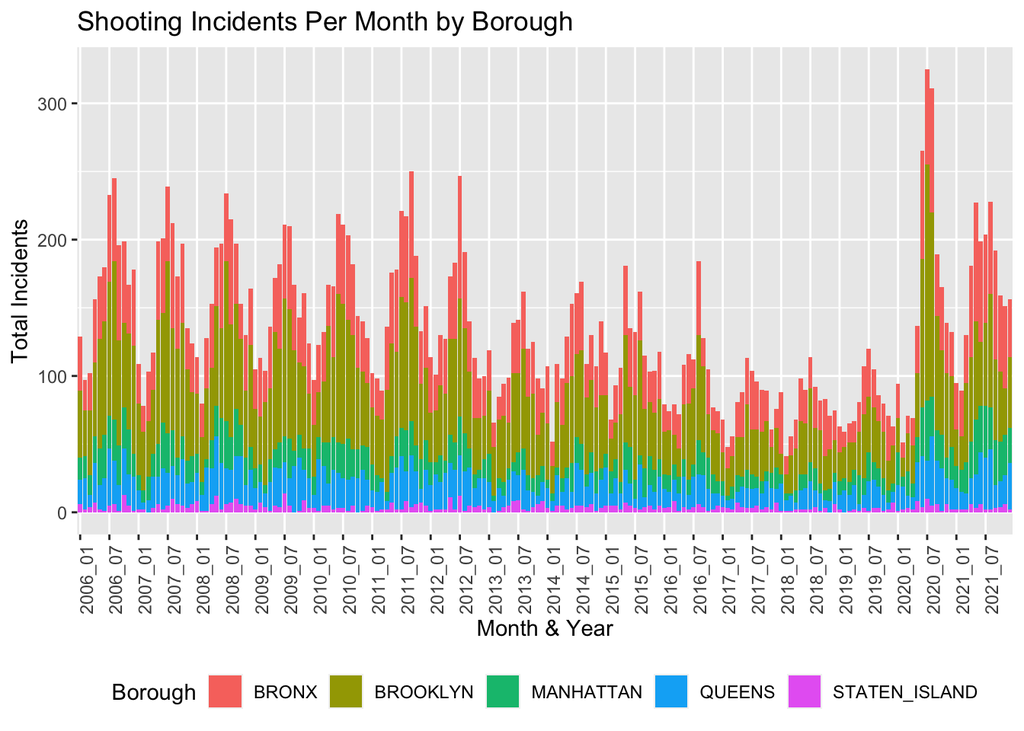

```r
#create stacked bar graph
ggplot(data = incidents_by_boroughs, aes(x = YEAR_MONTH, y = TOTAL_INCIDENTS, fill = factor(BORO))) +
  geom_bar(stat='identity') +
    theme(legend.position="bottom",
        axis.text.x = element_text(angle = 90)) + #place legend at bottom of graph
  scale_x_discrete(breaks = function(x){x[c(TRUE, FALSE, FALSE, FALSE, FALSE, FALSE)]}) + #label every six months in x axis
  labs(title = "Shooting Incidents Per Month by Borough",
       y = "Total Incidents",
       x = "Month & Year",
       fill = "Borough") #add labels
```

This graph shows the seasonal nature of shooting incidents between 2006 and 2021. It appears that the number of shooting incidents decrease in the winter months and rise in the summer. There also seems to be a higher amount of shooting in Brooklyn than any other borough, but this does not take into account population and does not show the average amount of shootings per resident of that borough. There is also an evident rise of shooting incidents in mid-2020.

## Shooting Incidents by Race

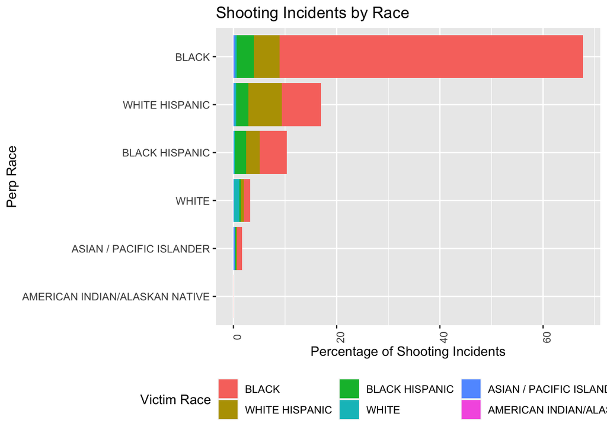

```r
#compare race on race shooting incidents
incidents_by_dem <- shooting_incidents %>%
    select(c(PERP_AGE_GROUP,PERP_SEX,PERP_RACE,VIC_AGE_GROUP,VIC_SEX,VIC_RACE)) #show relevant columns

incidents_by_dem <- incidents_by_dem[!(incidents_by_dem$VIC_RACE=="UNKNOWN" | incidents_by_dem$PERP_RACE=="UNKNOWN"),] #remove rows with missing or unknowndata (this creates bias!)
incidents_by_dem <- incidents_by_dem[complete.cases(incidents_by_dem), ]

incidents_by_race <- incidents_by_dem %>%
  select(c(PERP_RACE,VIC_RACE)) %>% #show relevant columns
    unite("PERP_VIC_RACE",
        c(PERP_RACE,VIC_RACE),
        sep = " ON ",
        na.rm = TRUE,
        remove = FALSE) %>% #combine columns for filtering later
  add_count(PERP_VIC_RACE) %>% #add column showing total incidents per perp & victim race
  distinct() %>% #remove duplicates
  mutate(PERCENTAGE = n / sum(n) * 100) #add column showing percentage of vic race per perp race

incidents_by_race$PERP_RACE <- factor(incidents_by_race$PERP_RACE, levels = c("BLACK",
    "WHITE HISPANIC", "BLACK HISPANIC", "WHITE", "ASIAN / PACIFIC ISLANDER", "AMERICAN INDIAN/ALASKAN NATIVE")) #rearrange order of perp races for ggplot

#create stacked bar chart showing percentage of victim races shot by perp race
ggplot(data = incidents_by_race, aes(x = reorder(VIC_RACE,n), y = PERCENTAGE, fill = factor(PERP_RACE))) +
  geom_bar(stat='identity') +
  coord_flip() + #turn chart 90 degrees
    theme(legend.position="bottom",
        axis.text.x = element_text(angle = 90)) + #place legend at bottom of graph
  labs(title = "Shooting Incidents by Race",
       y = "Percentage of Shooting Incidents",
       x = "Perp Race",
       fill = "Victim Race") #add labels
```

```r
#focus in on shooting incidents b/w 2 people of the same race
incidents_by_race <- incidents_by_dem %>%
  select(c(PERP_RACE,VIC_RACE)) %>% #show relevant columns
    unite("PERP_VIC_RACE",
        c(PERP_RACE,VIC_RACE),
        sep = " ON ",
        na.rm = TRUE,
        remove = FALSE) %>% #combine columns for filtering later
  add_count(PERP_VIC_RACE) %>% #add column showing number of incidents involving each combination of races
  add_count(PERP_RACE) %>% #add column showing number of incidents involving each perp race
  mutate(PERCENTAGE = n / nn * 100) %>% #calculate percentage of incidents involving each combination of races per total incidents involving perp of each race
  mutate(RACE_ON_RACE = PERP_RACE == VIC_RACE) %>% #show whether races of perp and victim are the same
  distinct() #remove duplicates
```

```
## Storing counts in `nn`, as `n` already present in input
## ℹ Use `name = "new_name"` to pick a new name.
```

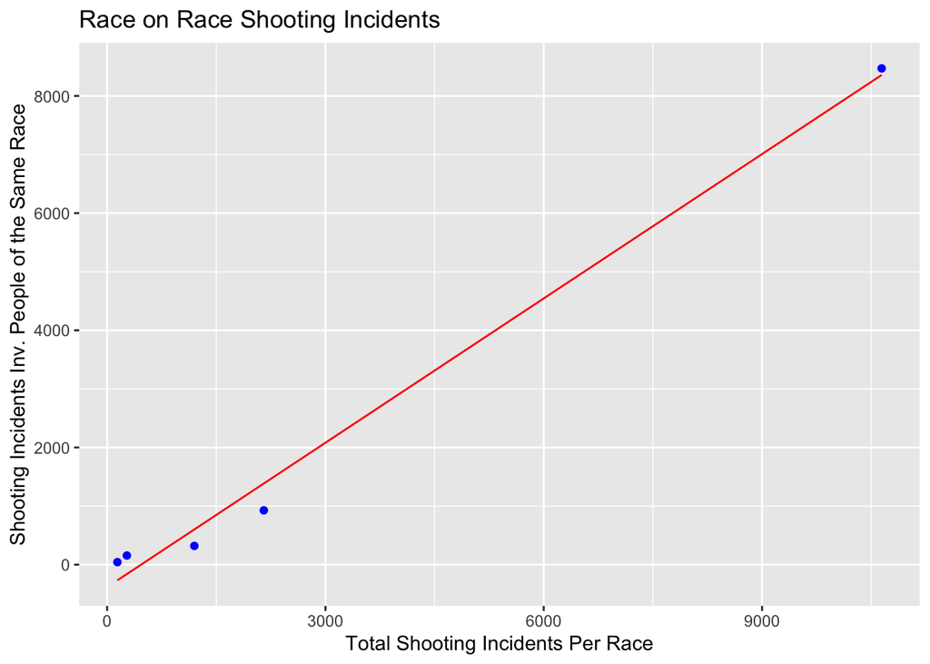

```r
incidents_by_race <- incidents_by_race[!(incidents_by_race$RACE_ON_RACE=="FALSE" | incidents_by_race$PERP_RACE=="UNKNOWN"),] #remove rows of incidents involving people of two different races and where perp race is unknown

#create chart showing the percentage of shooting incidents committed by each race that involves a victim of the same race & create model showing prediction line
mod <- lm(n ~ nn, data = incidents_by_race)
incidents_by_race_w_pred <- incidents_by_race %>% mutate(pred = predict(mod))
incidents_by_race_w_pred %>% ggplot() +
  geom_point(aes(x = nn, y = n), color = "blue") + #add points showing data
  geom_line(aes(x = nn, y = pred), color = "red") + #add prediction line
  labs(title = "Race on Race Shooting Incidents",
       y = "Shooting Incidents Inv. People of the Same Race",
       x = "Total Shooting Incidents Per Race") #add labels
```

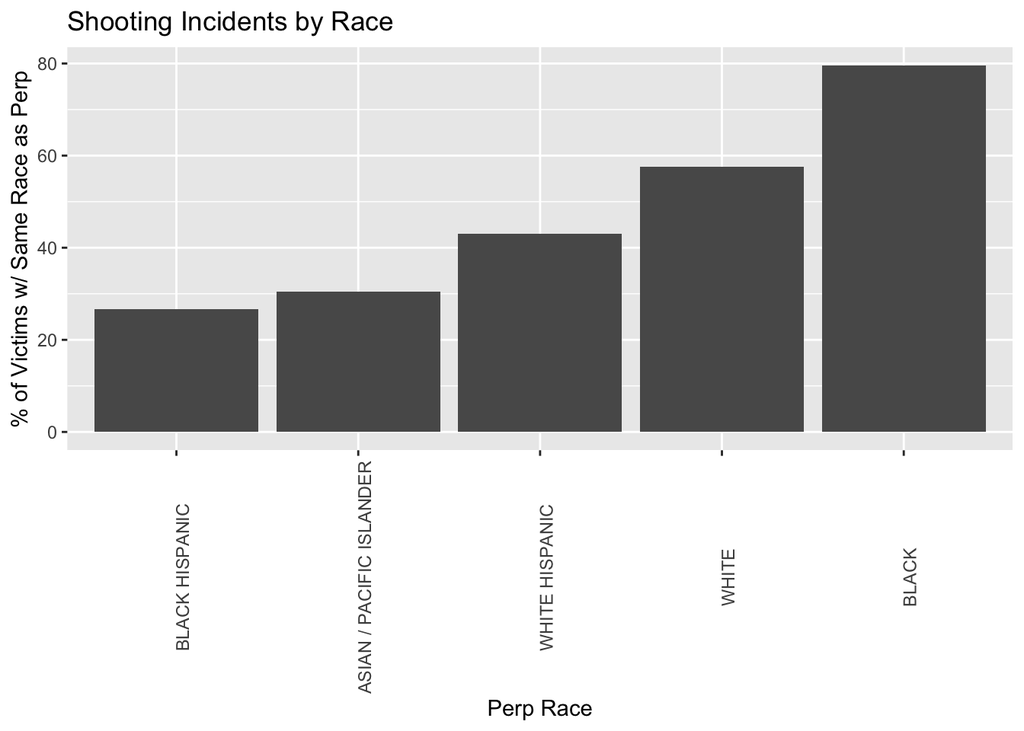

```r
#create bar graph showing the percentage of shooting incidents committed by each race that involves a victim of the same race
ggplot(data = incidents_by_race, aes(x = reorder(PERP_RACE,PERCENTAGE), y = PERCENTAGE)) +
  geom_bar(stat='identity') +
    theme(legend.position="bottom",
        axis.text.x = element_text(angle = 90)) + #place legend at bottom of graph
  labs(title = "Shooting Incidents by Race",
       y = "% of Victims w/ Same Race as Perp",
       x = "Perp Race") #add labels
```

I wanted to show the percentage of shooting incidents that were committed between two people of the same race for each race and see if there was a pattern. At first, it looked like the percentage was similar among all races and could be predicted but looking at the second graph, it appears that these percentages vary. There may be bias due to the fact that this data does not take into account people of mixed races as well as the amount of missing data pertaining to perp race.